# Part I - Loan Data from Prosper

## Introduction

> This data set contains 113,937 loans with 81 variables on each loan, including loan amount, borrower rate (or interest rate), current loan status, borrower income, and many others.

## Preliminary Wrangling

```python
# import all packages and set plots to be embedded inline
import numpy as np
import pandas as pd
import matplotlib.pyplot as plt
import seaborn as sb

%matplotlib inline
```

```python
df_loan=pd.read_csv('prosperLoanData.csv')
```

```python
df_loan.head(5)
```

|  | ListingKey | ListingNumber | ListingCreationDate | CreditGrade | Term | LoanStatus | ClosedDate | BorrowerAPR | BorrowerRate | LenderYield | ... | LP_ServiceFees | LP_CollectionFees | LP_GrossPrincipalLoss | LP_NetPrincipalLoss | LP_NonPrincipalRecoverypayments | PercentFunded | Recommendations | InvestmentFromFriendsCount | InvestmentFromFriendsAmount | Investors |
| --- | --- | --- | --- | --- | --- | --- | --- | --- | --- | --- | --- | --- | --- | --- | --- | --- | --- | --- | --- | --- | --- |
| 0 | 1021339766868145413AB3B | 193129 | 2007-08-26 19:09:29.263000000 | C | 36 | Completed | 2009-08-14 00:00:00 | 0.16516 | 0.1580 | 0.1380 | ... | -133.18 | 0.0 | 0.0 | 0.0 | 0.0 | 1.0 | 0 | 0 | 0.0 | 258 |
| 1 | 10273602499503308B223C1 | 1209647 | 2014-02-27 08:28:07.900000000 | NaN | 36 | Current | NaN | 0.12016 | 0.0920 | 0.0820 | ... | 0.00 | 0.0 | 0.0 | 0.0 | 0.0 | 1.0 | 0 | 0 | 0.0 | 1 |
| 2 | 0EE9337825851032864889A | 81716 | 2007-01-05 15:00:47.090000000 | HR | 36 | Completed | 2009-12-17 00:00:00 | 0.28269 | 0.2750 | 0.2400 | ... | -24.20 | 0.0 | 0.0 | 0.0 | 0.0 | 1.0 | 0 | 0 | 0.0 | 41 |
| 3 | 0EF5356002482715299901A | 658116 | 2012-10-22 11:02:35.010000000 | NaN | 36 | Current | NaN | 0.12528 | 0.0974 | 0.0874 | ... | -108.01 | 0.0 | 0.0 | 0.0 | 0.0 | 1.0 | 0 | 0 | 0.0 | 158 |
| 4 | 0F023589499656230C5E3E2 | 909464 | 2013-09-14 18:38:39.097000000 | NaN | 36 | Current | NaN | 0.24614 | 0.2085 | 0.1985 | ... | -60.27 | 0.0 | 0.0 | 0.0 | 0.0 | 1.0 | 0 | 0 | 0.0 | 20 |

5 rows × 81 columns

```python
df_loan.shape
```

```
(113937, 81)
```

```python
df_loan.info()
```

```
<class 'pandas.core.frame.DataFrame'>
RangeIndex: 113937 entries, 0 to 113936
Data columns (total 81 columns):
 #   Column                               Non-Null Count   Dtype
---  ------                               --------------   -----
 0   ListingKey                           113937 non-null  object
 1   ListingNumber                        113937 non-null  int64
 2   ListingCreationDate                  113937 non-null  object
 3   CreditGrade                          28953 non-null   object
 4   Term                                 113937 non-null  int64
 5   LoanStatus                           113937 non-null  object
 6   ClosedDate                           55089 non-null   object
 7   BorrowerAPR                          113912 non-null  float64
 8   BorrowerRate                         113937 non-null  float64
 9   LenderYield                          113937 non-null  float64
```

[output cut: 73 more lines]

```python
pd.set_option('display.max_columns', None)
```

```python
df_loan.describe()
```

|  | ListingNumber | Term | BorrowerAPR | BorrowerRate | LenderYield | EstimatedEffectiveYield | EstimatedLoss | EstimatedReturn | ProsperRating (numeric) | ProsperScore | ListingCategory (numeric) | EmploymentStatusDuration | CreditScoreRangeLower | CreditScoreRangeUpper | CurrentCreditLines | OpenCreditLines | TotalCreditLinespast7years | OpenRevolvingAccounts | OpenRevolvingMonthlyPayment | InquiriesLast6Months | TotalInquiries | CurrentDelinquencies | AmountDelinquent | DelinquenciesLast7Years | PublicRecordsLast10Years | PublicRecordsLast12Months | RevolvingCreditBalance | BankcardUtilization | AvailableBankcardCredit | … |
| --- | --- | --- | --- | --- | --- | --- | --- | --- | --- | --- | --- | --- | --- | --- | --- | --- | --- | --- | --- | --- | --- | --- | --- | --- | --- | --- | --- | --- | --- | --- |
| count | 1.139370e+05 | 113937.000000 | 113912.000000 | 113937.000000 | 113937.000000 | 84853.000000 | 84853.000000 | 84853.000000 | 84853.000000 | 84853.000000 | 113937.000000 | 106312.000000 | 113346.000000 | 113346.000000 | 106333.000000 | 106333.000000 | 113240.000000 | 113937.00000 | 113937.000000 | 113240.000000 | 112778.000000 | 113240.000000 | 106315.000000 | 112947.000000 | 113240.000000 | 106333.000000 | 1.063330e+05 | 106333.000000 | 106393.000000 | … |
| mean | 6.278857e+05 | 40.830248 | 0.218828 | 0.192764 | 0.182701 | 0.168661 | 0.080306 | 0.096068 | 4.072243 | 5.950067 | 2.774209 | 96.071582 | 685.567731 | 704.567731 | 10.317192 | 9.260164 | 26.754539 | 6.96979 | 398.292161 | 1.435085 | 5.584405 | 0.592052 | 984.507059 | 4.154984 | 0.312646 | 0.015094 | 1.759871e+04 | 0.561309 | 11210.225447 | … |
| std | 3.280762e+05 | 10.436212 | 0.080364 | 0.074818 | 0.074516 | 0.068467 | 0.046764 | 0.030403 | 1.673227 | 2.376501 | 3.996797 | 94.480605 | 66.458275 | 66.458275 | 5.457866 | 5.022644 | 13.637871 | 4.63097 | 447.159711 | 2.437507 | 6.429946 | 1.978707 | 7158.270157 | 10.160216 | 0.727868 | 0.154092 | 3.293640e+04 | 0.317918 | 19818.361309 | … |
| min | 4.000000e+00 | 12.000000 | 0.006530 | 0.000000 | -0.010000 | -0.182700 | 0.004900 | -0.182700 | 1.000000 | 1.000000 | 0.000000 | 0.000000 | 0.000000 | 19.000000 | 0.000000 | 0.000000 | 2.000000 | 0.00000 | 0.000000 | 0.000000 | 0.000000 | 0.000000 | 0.000000 | 0.000000 | 0.000000 | 0.000000 | 0.000000e+00 | 0.000000 | 0.000000 | … |
| 25% | 4.009190e+05 | 36.000000 | 0.156290 | 0.134000 | 0.124200 | 0.115670 | 0.042400 | 0.074080 | 3.000000 | 4.000000 | 1.000000 | 26.000000 | 660.000000 | 679.000000 | 7.000000 | 6.000000 | 17.000000 | 4.00000 | 114.000000 | 0.000000 | 2.000000 | 0.000000 | 0.000000 | 0.000000 | 0.000000 | 0.000000 | 3.121000e+03 | 0.310000 | 880.000000 | … |
| 50% | 6.005540e+05 | 36.000000 | 0.209760 | 0.184000 | 0.173000 | 0.161500 | 0.072400 | 0.091700 | 4.000000 | 6.000000 | 1.000000 | 67.000000 | 680.000000 | 699.000000 | 10.000000 | 9.000000 | 25.000000 | 6.00000 | 271.000000 | 1.000000 | 4.000000 | 0.000000 | 0.000000 | 0.000000 | 0.000000 | 0.000000 | 8.549000e+03 | 0.600000 | 4100.000000 | … |
| 75% | 8.926340e+05 | 36.000000 | 0.283810 | 0.250000 | 0.240000 | 0.224300 | 0.112000 | 0.116600 | 5.000000 | 8.000000 | 3.000000 | 137.000000 | 720.000000 | 739.000000 | 13.000000 | 12.000000 | 35.000000 | 9.00000 | 525.000000 | 2.000000 | 7.000000 | 0.000000 | 0.000000 | 3.000000 | 0.000000 | 0.000000 | 1.952100e+04 | 0.840000 | 13180.000000 | … |
| max | 1.255725e+06 | 60.000000 | 0.512290 | 0.497500 | 0.492500 | 0.319900 | 0.366000 | 0.283700 | 7.000000 | 11.000000 | 20.000000 | 755.000000 | 880.000000 | 899.000000 | 59.000000 | 54.000000 | 136.000000 | 51.00000 | 14985.000000 | 105.000000 | 379.000000 | 83.000000 | 463881.000000 | 99.000000 | 38.000000 | 20.000000 | 1.435667e+06 | 5.950000 | 646285.000000 | … |

### What is the structure of your dataset?

> 113937, 81

### What is/are the main feature(s) of interest in your dataset?

> This is a very critical question for banks and loan companies in order to minimize the default risk and and to set the right interest rate (including setting a proper risk premium). This investigation might help to find out what factors predict the outcome of a loan best.

### What features in the dataset do you think will help support your investigation into your feature(s) of interest?

Term (The length of the loan expressed in months) ProsperScore (custom risk score) EmploymentStatus (The employment status of the borrower) MonthlyLoanPayment (The scheduled monthly loan payment) IncomeRange (The income range of the borrower at the time the listing was created) BorrowerRate (The Borrower's interest rate for this loan) CurrentDelinquencies OpenCreditLines (Number of open credit line) TotalProsperPaymentsBilled (number of on time payments the borrower made on Prosper loans at the time they created this listing) Recommendations (Number of recommendations the borrower had at the time the listing was created) Whereby I expect to have ProsperScore, EmploymentStatus, BorrowerRate, (high interest rate are associated with higher default risk) and Income Range have the strongest effect on the loan's outcome status.

## Univariate Exploration

```python
df_loan['ProsperScore'] = df_loan['ProsperScore'].astype('category')
df_loan['Term'] = df_loan['Term'].astype('category')
df_loan['IncomeRange'] = df_loan['IncomeRange'].astype('category')
df_loan['EmploymentStatus'] = df_loan['EmploymentStatus'].astype('category')
df_loan['LoanStatus'] = df_loan['LoanStatus'].astype('category')
df_loan.info()
```

[output not shown]

[output cut: 75 more lines]

### Distribution of loan status

```python
df_loan.LoanStatus.unique()
```

```
array(['Completed', 'Current', 'Past Due (1-15 days)', 'Defaulted',
       'Chargedoff', 'Past Due (16-30 days)', 'Cancelled',
       'Past Due (61-90 days)', 'Past Due (31-60 days)',
       'Past Due (91-120 days)', 'FinalPaymentInProgress',
       'Past Due (>120 days)'], dtype=object)
```

```python
df_loan.replace(to_replace=['Past Due (1-15 days)','Past Due (16-30 days)','Past Due (61-90 days)', 'Past Due (31-60 days)',
       'Past Due (91-120 days)','Past Due (>120 days)'],value='Past Due',inplace=True)
```

```python
load_status_df=df_loan.groupby('LoanStatus').size().div(df_loan.shape[0])
```

```python
load_status_df
```

```
LoanStatus
Cancelled                 0.000044
Chargedoff                0.105251
Completed                 0.334167
Current                   0.496555
Defaulted                 0.044042
FinalPaymentInProgress    0.001799
Past Due                  0.018142
dtype: float64
```

#### What are the outcome of loans?

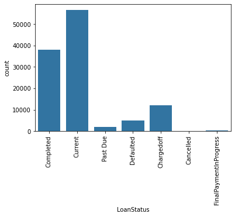

```python
sb.countplot(data=df_loan,x='LoanStatus',color=sb.color_palette()[0])
plt.xticks(rotation=90);
```

#### What are the length of given loans?

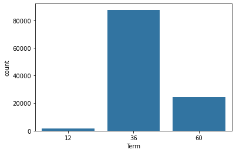

```python
sb.countplot(data=df_loan,x='Term',color=sb.color_palette()[0]);
```

#### What is the distribution of loans in various states?

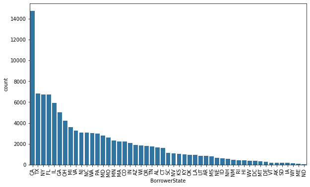

```python
plt.figure(figsize=(10,6))
order_state=df_loan.BorrowerState.value_counts().sort_values(ascending=False).index
sb.countplot(data=df_loan,x='BorrowerState',color=sb.color_palette()[0],order=order_state)
plt.xticks(rotation=90);
```

```python
df_loan.ClosedDate=pd.to_datetime(df_loan.ClosedDate).dt.year
```

#### What years these loans were closed?

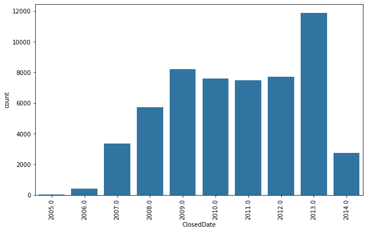

```python
plt.figure(figsize=(10,6))

sb.countplot(data=df_loan,x='ClosedDate',color=sb.color_palette()[0],)
plt.xticks(rotation=90);
```

#### What is the distribution of APRs?

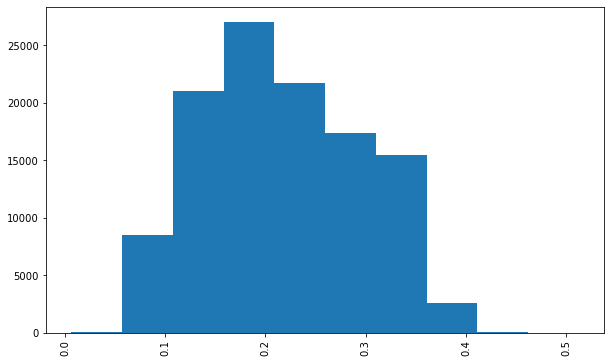

```python
plt.figure(figsize=(10,6))

plt.hist(data=df_loan,x='BorrowerAPR',color=sb.color_palette()[0])
plt.xticks(rotation=90);
```

#### What are the credit ratings that were given to the borrowers at the time of inquiries?

```python
df_loan.ProsperScore.unique()
```

```
array([nan,  7.,  9.,  4., 10.,  2., 11.,  8.,  5.,  3.,  6.,  1.])
```

```python
df_loan['ProsperScore']=df_loan.ProsperScore.astype('category')
```

```python
df_loan_mod=df_loan[df_loan.ProsperScore!=11]
```

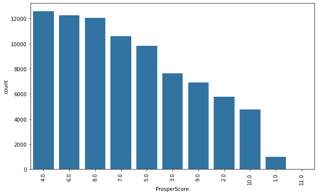

```python
plt.figure(figsize=(10,6))

sb.countplot(data=df_loan_mod,x='ProsperScore',color=sb.color_palette()[0],order = df_loan_mod['ProsperScore'].value_counts().index)
plt.xticks(rotation=90);
```

I wonder why people with scores as low as 1 and 2 were given loans.

#### What capital structure the borrowers had prior to asking for loans?(Debt to income ratio)

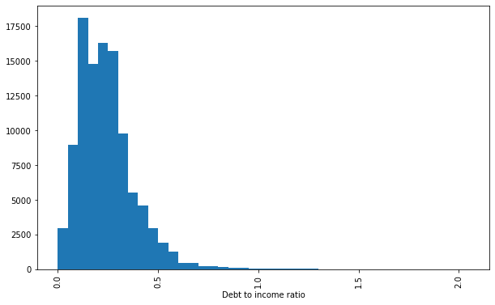

```python
plt.figure(figsize=(10,6))
bins=np.arange(0,2+0.1,0.05)
plt.hist(data=df_loan,x='DebtToIncomeRatio',color=sb.color_palette()[0],bins=bins)
plt.xticks(rotation=90);
plt.xlabel('Debt to income ratio')
```

#### Most borrowers have a good debt to income ratio(under 0.5) which in turn could lower the risk of defualt

### What were borrowers' income range?

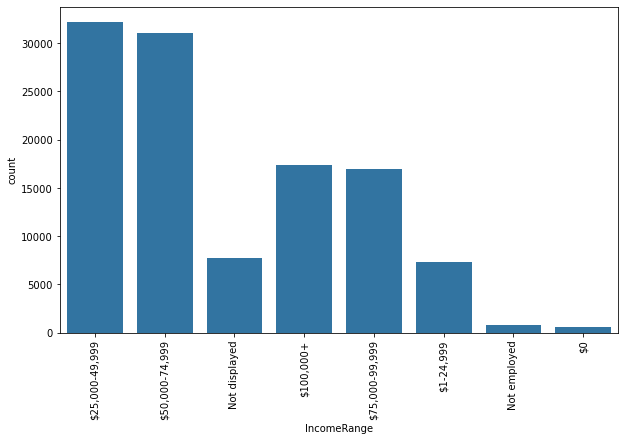

```python
plt.figure(figsize=(10,6))

sb.countplot(data=df_loan,x='IncomeRange',color=sb.color_palette()[0])
plt.xticks(rotation=90);
```

#### Majority of borrowrs are in lower range of income

#### What is the distribution of amount of the loans?

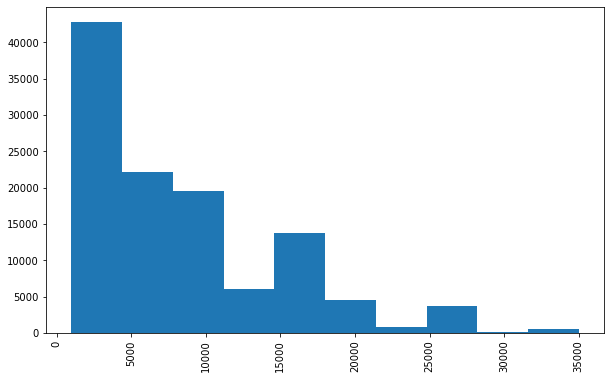

```python
plt.figure(figsize=(10,6))

plt.hist(data=df_loan,x='LoanOriginalAmount',color=sb.color_palette()[0])
plt.xticks(rotation=90);
```

#### This chart could signify that due to borrowers being in the lower range of income they were given loans that would be managble for them

#### What is monthly loan payment look like?

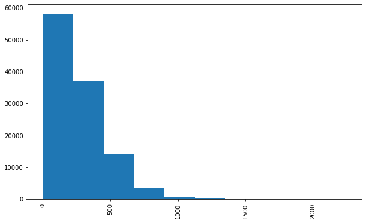

```python
plt.figure(figsize=(10,6))

plt.hist(data=df_loan,x='MonthlyLoanPayment',color=sb.color_palette()[0])
plt.xticks(rotation=90);
```

```python
df_loan[df_loan.MonthlyLoanPayment==0].MonthlyLoanPayment.value_counts()
```

```
0.0    935
Name: MonthlyLoanPayment, dtype: int64
```

```python
df_loan[df_loan.MonthlyLoanPayment==0].groupby('LoanStatus').size()
```

```
LoanStatus
Completed                 800
Defaulted                 131
FinalPaymentInProgress      4
dtype: int64
```

#### Since loan amounts were low, their monthly obligations were low as well

I noticed some of the monthly payments were zero but digging deeper I realized most of them had payed off their loans

```python
df_loan.Recommendations.unique()
```

```
array([ 0,  2,  1,  4,  3,  9,  5, 16, 39, 21,  7, 14,  8,  6, 24, 19, 18],
      dtype=int64)
```

### How many poeple either recommended the borrower or invested in the borrower's investment?

```python
df_loan['TotalNumberInvestors']=df_loan.InvestmentFromFriendsCount+df_loan.Investors+df_loan.Recommendations
```

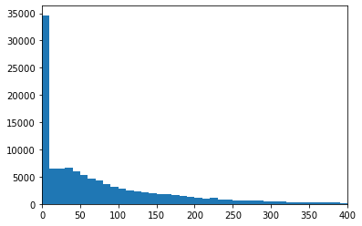

```python
bins=np.arange(0,df_loan.TotalNumberInvestors.max()+10,10)
plt.hist(data=df_loan,x='TotalNumberInvestors',color=sb.color_palette()[0],bins=bins);
plt.xlim((0,400));
```

### Did borrowers had previous borrowing history?

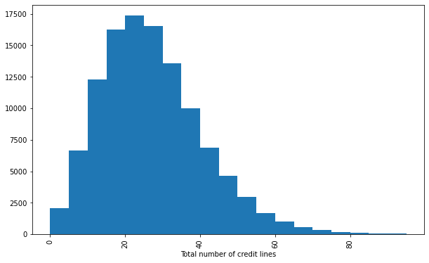

```python
plt.figure(figsize=(10,6))
bins=np.arange(0,100,5)
plt.hist(data=df_loan,x='TotalCreditLinespast7years',color=sb.color_palette()[0],bins=bins)
plt.xticks(rotation=90);
plt.xlabel('Total number of credit lines')
```

#### Most borrowrs had borrwing history

### Had borrowers have defaulted on their previous loans?

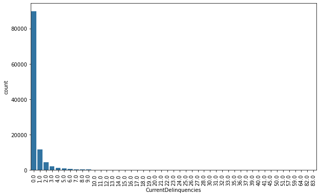

```python
plt.figure(figsize=(10,6))
sb.countplot(data=df_loan,x='CurrentDelinquencies',color=sb.color_palette()[0])
plt.xticks(rotation=90);
```

#### There a few poeple that had poor history on their previous loans

## Bivariate Exploration

[output not shown]

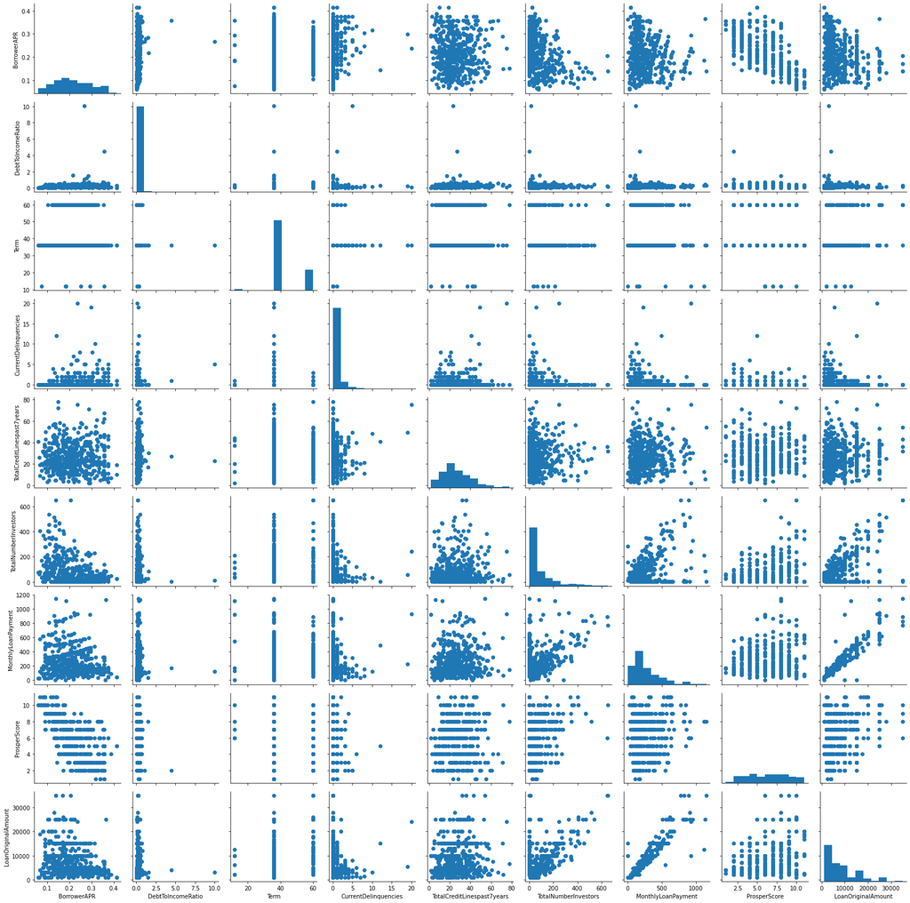

```python
samples=np.random.choice(df_loan.shape[0],500,replace=False)
loan_samples=df_loan.iloc[samples,:]
g=sb.PairGrid(data=loan_samples,vars=['BorrowerAPR','DebtToIncomeRatio','Term','CurrentDelinquencies','TotalCreditLinespast7years','TotalNumberInvestors','MonthlyLoanPayment','ProsperScore','LoanOriginalAmount'])
g.map_diag(plt.hist);
g.map_offdiag(plt.scatter);
```

#### Are borrowers with more debt to income ratio prone to default?

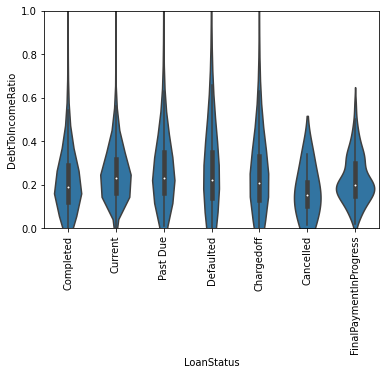

```python
sb.violinplot(data=df_loan, x='LoanStatus', y='DebtToIncomeRatio', color=sb.color_palette()[0])
plt.ylim((0,1))
plt.xticks(rotation=90);
```

#### The plot shows that loans that are charged-off, past dued or defaulted have slighlty higher than average debt to income ratios.

#### Do borrowers with higher APR tend to default more?

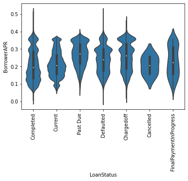

```python
sb.violinplot(data=df_loan, x='LoanStatus', y='BorrowerAPR', color=sb.color_palette()[0])

plt.xticks(rotation=90);
```

#### The plot shows that loans that are charged-off, past dued or defaulted have higher than average interest rates on their loans.

### Is shoter loan term less exposed to default?

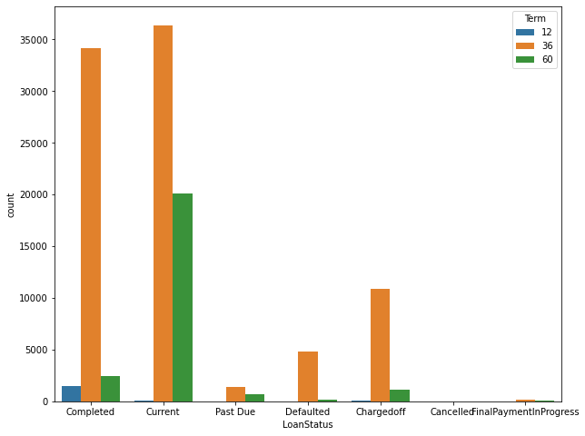

```python
plt.figure(figsize=(10,8))
sb.countplot(data=df_loan,x='LoanStatus',hue='Term')
```

#### It seems that the terms in which the loans have to be payed off do not have an impact on the status of the loans

#### There is no indications that the duration of a loan could expose the borrower to more risk of default

#### Does having past insolvent debt affect future default?

```python
df_loan['delinquencyMod']=df_loan.CurrentDelinquencies.apply(lambda x:8 if x>=9 else x)
```

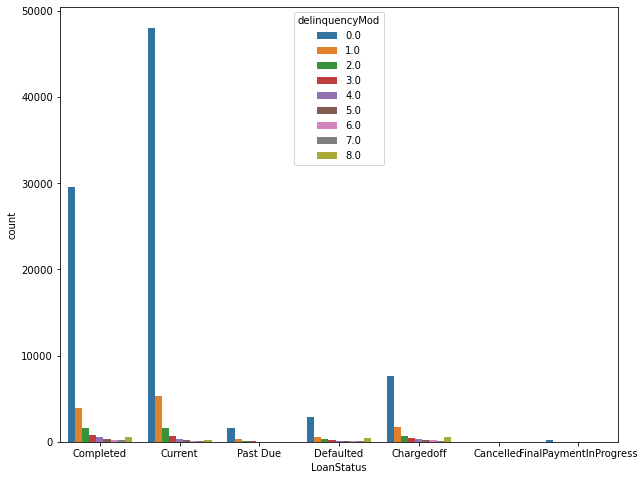

```python
plt.figure(figsize=(10,8))
sb.countplot(data=df_loan,x='LoanStatus',hue='delinquencyMod')
```

#### It is interesting to see in every category (LoanStatus) people with zero previous delinquency have higher counts. But generally number of deliquency in the past does not have any impact on the loan status.

#### Are borrowrs who have less investors supporting them indicitive of being more default prone?

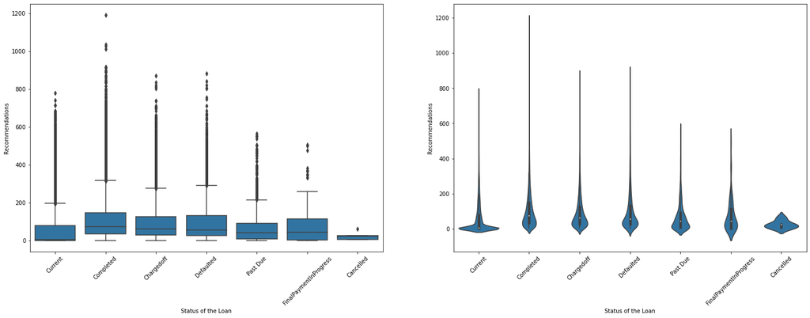

```python
plt.figure(figsize = [25, 18])

plt.subplot(2, 2, 1)
sb.boxplot(data = df_loan, x = 'LoanStatus', y = 'TotalNumberInvestors', color = sb.color_palette()[0], order = df_loan['LoanStatus'].value_counts().index)
plt.xticks(rotation=45)
plt.xlabel('Status of the Loan')
plt.ylabel('Recommendations')

plt.subplot(2, 2, 2)
sb.violinplot(data = df_loan, x = 'LoanStatus', y = 'TotalNumberInvestors', color =sb.color_palette()[0], order = df_loan['LoanStatus'].value_counts().index)
plt.xticks(rotation=45)
plt.xlabel('Status of the Loan')
plt.ylabel('Recommendations');
```

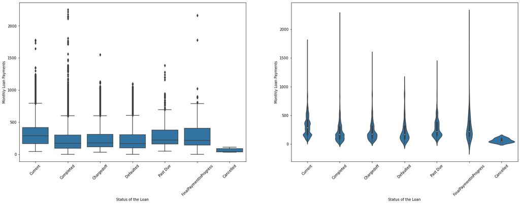

```python
plt.figure(figsize = [25, 18])

plt.subplot(2, 2, 1)
sb.boxplot(data = df_loan, x = 'LoanStatus', y = 'MonthlyLoanPayment', color = sb.color_palette()[0], order = df_loan['LoanStatus'].value_counts().index)
plt.xticks(rotation=45)
plt.xlabel('Status of the Loan')
plt.ylabel('Monthly Loan Payments')

plt.subplot(2, 2, 2)
sb.violinplot(data = df_loan, x = 'LoanStatus', y = 'MonthlyLoanPayment', color = sb.color_palette()[0], order = df_loan['LoanStatus'].value_counts().index)
plt.xticks(rotation=45)
plt.xlabel('Status of the Loan')
plt.ylabel('Monthly Loan Payments');
```

#### Does the scoring system that is assigned to borrowes help identify potentioal risky borrowers?

```python
ct_counts = df_loan.groupby(['LoanStatus', 'ProsperScore']).size()
ct_counts = ct_counts.reset_index(name = 'count')
ct_counts = ct_counts.pivot(index = 'ProsperScore', columns = 'LoanStatus', values = 'count')
ct_counts
```

| LoanStatus ProsperScore | Cancelled | Chargedoff | Completed | Current | Defaulted | FinalPaymentInProgress | Past Due |
| --- | --- | --- | --- | --- | --- | --- | --- |
| 1.0 | 0 | 235 | 341 | 337 | 37 | 2 | 40 |
| 2.0 | 0 | 377 | 848 | 4196 | 70 | 23 | 252 |
| 3.0 | 0 | 414 | 1077 | 5804 | 75 | 20 | 252 |
| 4.0 | 0 | 784 | 1828 | 9476 | 119 | 28 | 360 |
| 5.0 | 0 | 907 | 2212 | 6222 | 165 | 25 | 282 |
| 6.0 | 0 | 925 | 2847 | 7981 | 173 | 25 | 327 |
| 7.0 | 0 | 662 | 2357 | 7210 | 135 | 16 | 217 |
| 8.0 | 0 | 666 | 3711 | 7265 | 139 | 39 | 233 |
| 9.0 | 0 | 309 | 2836 | 3612 | 71 | 13 | 70 |
| 10.0 | 0 | 57 | 1576 | 3054 | 20 | 11 | 32 |
| 11.0 | 0 | 0 | 31 | 1419 | 1 | 3 | 2 |

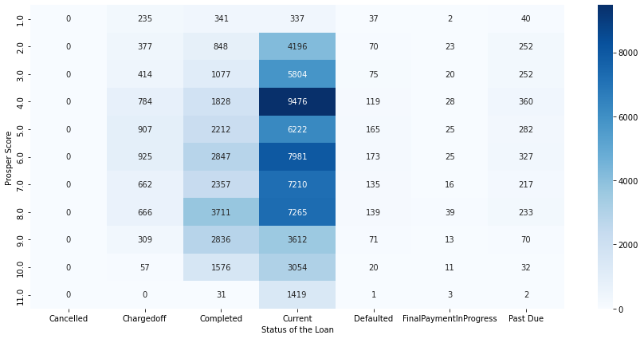

```python
plt.figure(figsize = [15,7])
mask = ct_counts.isnull()
sb.heatmap(ct_counts, annot = True, fmt = 'd', cmap = 'Blues',mask = mask)
plt.xlabel('Status of the Loan')
plt.ylabel('Prosper Score');
```

#### The Prosper Score seem to affect the outcome of the loan: so have the most borrower an Prosper Score of 8 when a loan is completed, while most borrower with defaulted and charged-off loans have Prosper Score of 6. Furthermore, the most comon Prosper Score for borrowers with loans that have past due payments is 4.

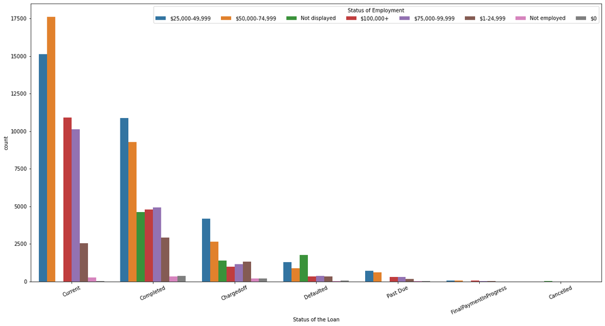

```python
#plotting EmploymentStatus (Status of Employment) against LoanStatus with help of a heat map
plt.figure(figsize = [20,10])
sb.countplot(data = df_loan, x = 'LoanStatus', hue = 'IncomeRange', order = df_loan['LoanStatus'].value_counts().index)
plt.legend(loc = 1, ncol = 8, title = 'Status of Employment')
plt.xticks(rotation = 25)
plt.xlabel('Status of the Loan');
```

#### It can be seen that the higher the income group is the less risky it is that borrowers charge off,defualt or delay on their loans

## Observations:

- relationship between the Debt to income and the outcome of the loan: loans that are charged- off, loans with past due payments and defaulted loans have in average higher monthly Debt-to-Income ratio
- loans that are charged-off, loans with past due payments and defaulted loans have in average higher interest rates than loans that are completed
- the highest interest rates are asscociated with loans that are charged-off and with loans that have past due payments
- It is interesting to see in every category (LoanStatus) people with zero previous delinquency have higher counts. But generally number of deliquency in the past does not have any impact on the loan status.
- The Prosper Score seem to affect the outcome of the loan: so have the most borrower an Prosper Score of 8 when a loan is completed, while most borrower with defaulted and charged-off loans have an Prosper Score of 6. Furthermore, the most comon Prosper Score for borrowers with loans that have past due payments is 4.

## Multivariate Exploration

#### I would like to further investigate the relationship between the status/outcome of a loan and the Prosper Score in relation to the interest rate, On time Payments since they seem to have the strongest impact on the outcome of a loan.

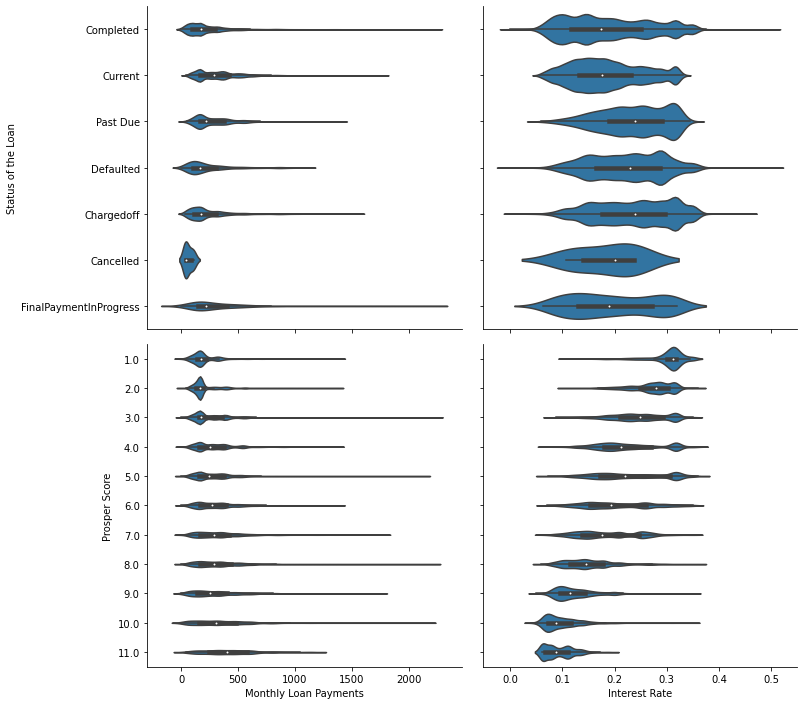

```python
g = sb.PairGrid(data = df_loan, x_vars = ['MonthlyLoanPayment', 'BorrowerRate'],
                y_vars = ['LoanStatus','ProsperScore'], height = 5, aspect = 1)
g.map(sb.violinplot,color=sb.color_palette()[0])
g.axes[1,0].set_xlabel('Monthly Loan Payments')
g.axes[1,1].set_xlabel('Interest Rate')
g.axes[0,0].set_ylabel('Status of the Loan')
g.axes[1,0].set_ylabel('Prosper Score')
```